# Independent T-Test: Sex Differences in Lateral Hop Biomechanics

This report examines lateral hopping biomechanics and performance data:

1. Demographic information (age, sex, height, mass)
2. Biomechanical angles during landing phase (KFlex, HFlex, TFlex, KFPPA, HFPPA, PD, LTM)
3. Performance data (hop distances) for four directions: LL, LR, RL, RR

# Demographic Data Analysis

## Summary Statistics

```r
demo_summary <- demo_data %>%
  summarise(
    n = n(),
    Age_Mean = mean(Age, na.rm = TRUE),
    Age_SD = sd(Age, na.rm = TRUE),
    Mass_Mean = mean(Mass, na.rm = TRUE),
    Mass_SD = sd(Mass, na.rm = TRUE),
    Height_Mean = mean(Height, na.rm = TRUE),
    Height_SD = sd(Height, na.rm = TRUE)
  )

kable(demo_summary,
      caption = "Overall Demographic Summary",
      digits = 2,
      col.names = c("N", "Age (M)", "Age (SD)", "Mass (M)", "Mass (SD)", "Height (M)", "Height (SD)")) %>%
  kable_styling(bootstrap_options = c("striped", "hover", "condensed"), full_width = FALSE)
```

Overall Demographic Summary

| N | Age (M) | Age (SD) | Mass (M) | Mass (SD) | Height (M) | Height (SD) |
| --- | --- | --- | --- | --- | --- | --- |
| 40 | 25.02 | 3.58 | 70.66 | 12.02 | 170.74 | 7.8 |

```r
demo_by_sex <- demo_data %>%
  group_by(Sex) %>%
  summarise(
    n = n(),
    Age_Mean = mean(Age, na.rm = TRUE),
    Age_SD = sd(Age, na.rm = TRUE),
    Mass_Mean = mean(Mass, na.rm = TRUE),
    Mass_SD = sd(Mass, na.rm = TRUE),
    Height_Mean = mean(Height, na.rm = TRUE),
    Height_SD = sd(Height, na.rm = TRUE)
  )

kable(demo_by_sex,
      caption = "Demographic Summary by Sex",
      digits = 2,
      col.names = c("Sex", "N", "Age (M)", "Age (SD)", "Mass (M)", "Mass (SD)", "Height (M)", "Height (SD)")) %>%
  kable_styling(bootstrap_options = c("striped", "hover", "condensed"), full_width = FALSE)
```

Demographic Summary by Sex

| Sex | N | Age (M) | Age (SD) | Mass (M) | Mass (SD) | Height (M) | Height (SD) |
| --- | --- | --- | --- | --- | --- | --- | --- |
| F | 20 | 24.15 | 2.89 | 62.06 | 8.71 | 166.90 | 6.82 |
| M | 20 | 25.90 | 4.04 | 79.26 | 8.05 | 174.57 | 6.88 |

## Demographic Distributions

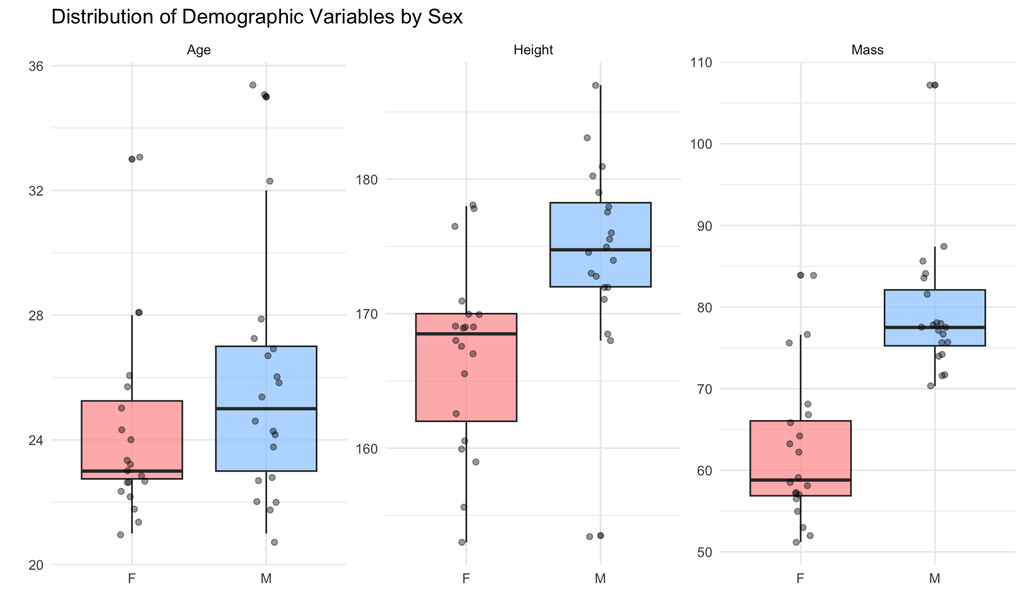

```r
demo_long <- demo_data %>%
  pivot_longer(cols = c(Age, Mass, Height), names_to = "Measure", values_to = "Value")

ggplot(demo_long, aes(x = Sex, y = Value, fill = Sex)) +
  geom_boxplot(alpha = 0.7) +
  geom_jitter(width = 0.1, alpha = 0.4) +
  facet_wrap(~Measure, scales = "free_y") +
  theme_minimal(base_size = 12) +
  labs(title = "Distribution of Demographic Variables by Sex", x = "", y = "") +
  scale_fill_manual(values = c("F" = "#FF9999", "M" = "#99CCFF")) +
  theme(legend.position = "none")
```

```r
t_test_results <- data.frame(
  Variable = c("Age", "Mass", "Height"),
  t_value = c(
    t.test(Age ~ Sex, data = demo_data)$statistic,
    t.test(Mass ~ Sex, data = demo_data)$statistic,
    t.test(Height ~ Sex, data = demo_data)$statistic
  ),
  p_value = c(
    t.test(Age ~ Sex, data = demo_data)$p.value,
    t.test(Mass ~ Sex, data = demo_data)$p.value,
    t.test(Height ~ Sex, data = demo_data)$p.value
  )
)

kable(t_test_results,
      caption = "T-Test Results for Demographics (Male vs Female)",
      digits = 3,
      col.names = c("Variable", "t-value", "p-value")) %>%
  kable_styling(bootstrap_options = c("striped", "hover", "condensed"), full_width = FALSE)
```

T-Test Results for Demographics (Male vs Female)

| Variable | t-value | p-value |
| --- | --- | --- |
| Age | -1.576 | 0.124 |
| Mass | -6.484 | 0.000 |
| Height | -3.547 | 0.001 |

# Biomechanical Angles Analysis

```r
angle_types <- c("KFlex", "HFlex", "Tflex", "KFPPA", "HFPPA", "PD", "LTM")
hop_directions <- c("LL", "LR", "RL", "RR")

angles_long <- angles_data %>%
  pivot_longer(
    cols = matches("^(LL|LR|RL|RR)_"),
    names_to = c("Direction", "Angle"),
    names_pattern = "(.+)_(.+)",
    values_to = "Value"
  )
```

## Descriptive Statistics by Sex

```r
angles_summary <- angles_long %>%
  group_by(Sex, Direction, Angle) %>%
  summarise(
    Mean = mean(Value, na.rm = TRUE),
    SD = sd(Value, na.rm = TRUE),
    .groups = "drop"
  )

for(dir in hop_directions) {
  cat(paste("\n###", dir, "Direction\n"))

  angles_summary %>%
    filter(Direction == dir) %>%
    select(-Direction) %>%
    pivot_wider(names_from = Sex, values_from = c(Mean, SD)) %>%
    kable(caption = paste("Kinematic Angles for", dir, "Direction"), digits = 2) %>%
    kable_styling(bootstrap_options = c("striped", "hover", "condensed"), full_width = FALSE) %>%
    print()
}
```

### LL Direction

Kinematic Angles for LL Direction

| Angle | Mean_F | Mean_M | SD_F | SD_M |
| --- | --- | --- | --- | --- |
| HFPPA | 92.52 | 99.47 | 8.03 | 6.73 |
| HFlex | 44.70 | 58.19 | 11.33 | 17.17 |
| KFPPA | 12.21 | 6.06 | 7.78 | 9.84 |
| KFlex | 53.25 | 54.69 | 11.92 | 9.19 |
| LTM | 8.63 | 8.88 | 5.20 | 3.84 |
| PD | 2.57 | 5.15 | 8.15 | 5.54 |
| Tflex | 16.72 | 24.16 | 10.09 | 10.42 |

### LR Direction

Kinematic Angles for LR Direction

| Angle | Mean_F | Mean_M | SD_F | SD_M |
| --- | --- | --- | --- | --- |
| HFPPA | 91.23 | 101.57 | 8.14 | 8.60 |
| HFlex | 54.05 | 60.45 | 20.23 | 16.08 |
| KFPPA | 12.34 | 12.22 | 6.20 | 6.86 |
| KFlex | 55.24 | 55.99 | 13.73 | 8.56 |
| LTM | 20.20 | 17.20 | 3.97 | 6.89 |
| PD | 0.39 | 1.41 | 6.67 | 5.45 |
| Tflex | 23.21 | 27.87 | 11.81 | 11.19 |

### RL Direction

Kinematic Angles for RL Direction

| Angle | Mean_F | Mean_M | SD_F | SD_M |
| --- | --- | --- | --- | --- |
| HFPPA | 94.98 | 101.53 | 9.05 | 7.74 |
| HFlex | 53.54 | 59.35 | 19.04 | 14.72 |
| KFPPA | 11.54 | 11.66 | 8.16 | 6.50 |
| KFlex | 55.24 | 55.93 | 13.24 | 8.45 |
| LTM | 12.13 | 12.37 | 4.81 | 6.30 |
| PD | 0.30 | 2.23 | 8.29 | 6.25 |
| Tflex | 20.41 | 24.87 | 11.81 | 9.00 |

### RR Direction

Kinematic Angles for RR Direction

| Angle | Mean_F | Mean_M | SD_F | SD_M |
| --- | --- | --- | --- | --- |
| HFPPA | 89.35 | 98.87 | 5.58 | 9.56 |
| HFlex | 48.07 | 64.20 | 12.01 | 13.28 |
| KFPPA | 14.39 | 9.87 | 7.23 | 4.44 |
| KFlex | 56.85 | 58.07 | 11.83 | 9.14 |
| LTM | 13.84 | 12.71 | 5.44 | 6.59 |
| PD | 0.85 | 4.88 | 6.03 | 6.43 |
| Tflex | 19.41 | 28.00 | 8.80 | 10.31 |

## Angle Visualizations

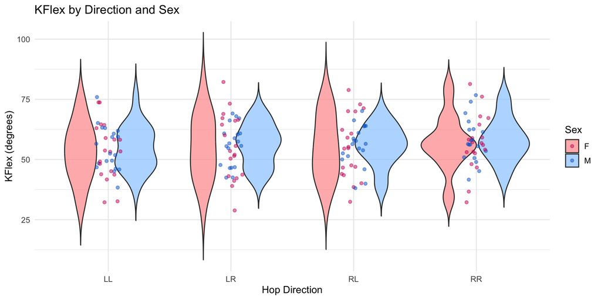

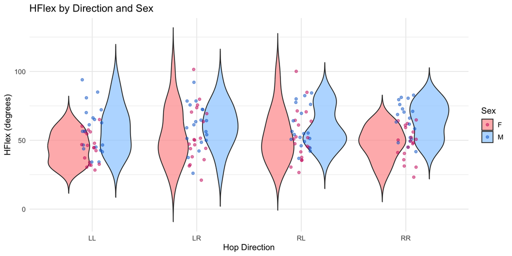

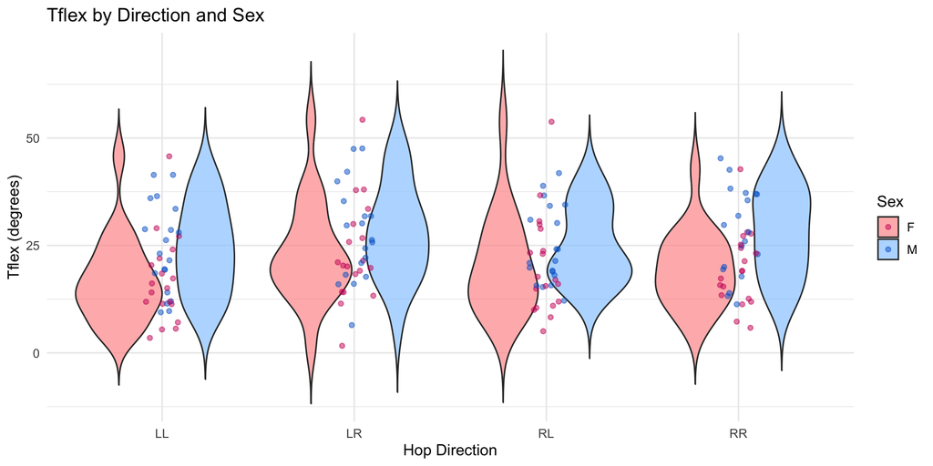

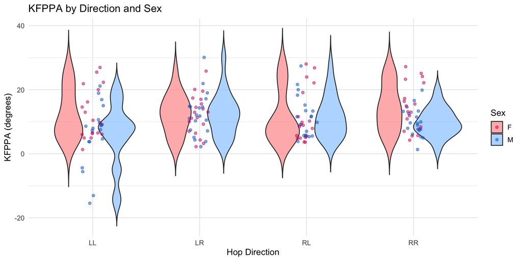

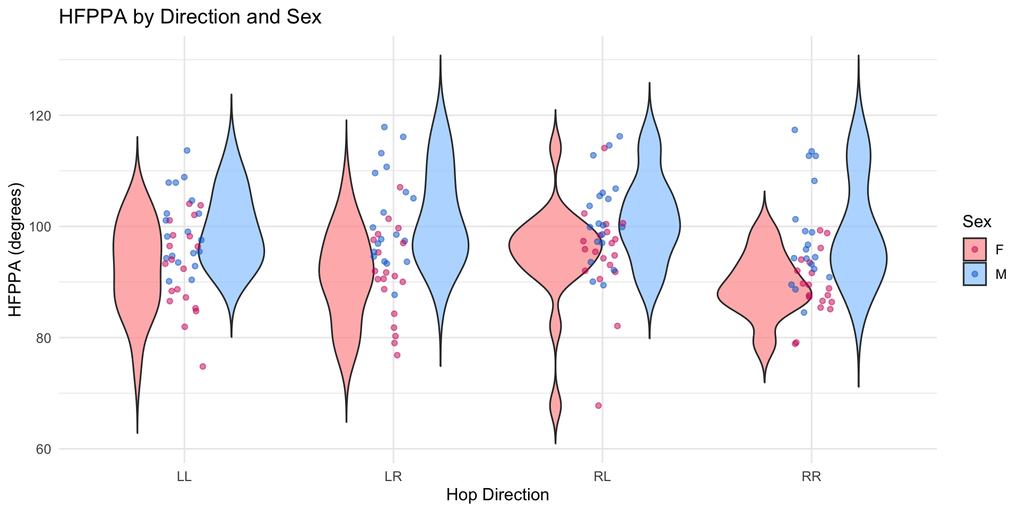

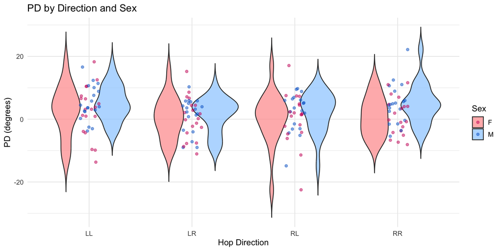

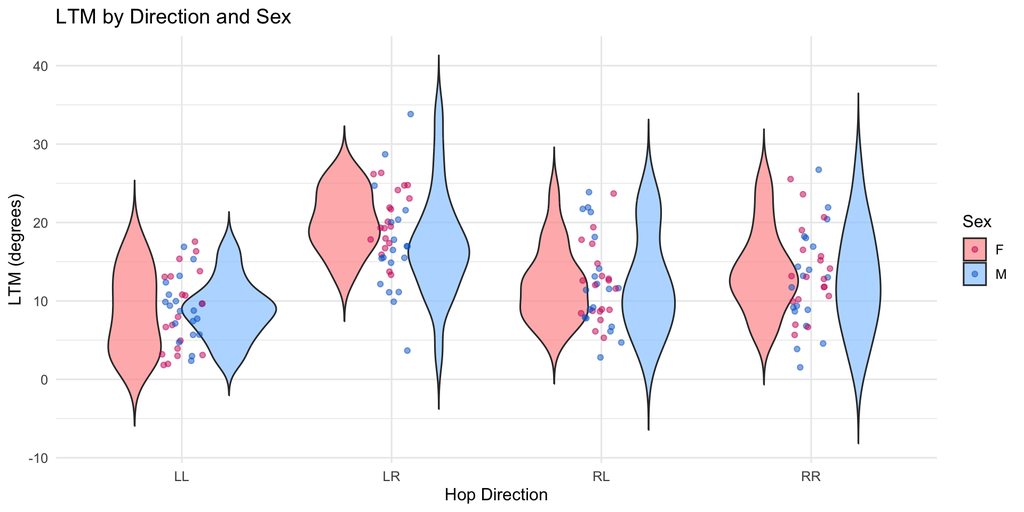

```r
for(angle in angle_types) {
  p <- angles_long %>%
    filter(Angle == angle) %>%
    ggplot(aes(x = Direction, y = Value, fill = Sex)) +
    geom_violin(alpha = 0.7, trim = FALSE) +
    geom_jitter(aes(color = Sex), width = 0.1, alpha = 0.5, size = 1.5) +
    theme_minimal(base_size = 12) +
    labs(title = paste(angle, "by Direction and Sex"),
         x = "Hop Direction", y = paste(angle, "(degrees)")) +
    scale_fill_manual(values = c("F" = "#FF9999", "M" = "#99CCFF")) +
    scale_color_manual(values = c("F" = "#CC0066", "M" = "#0066CC"))

  print(p)
}
```

## T-Tests with Effect Sizes

```r
t_test_angles <- angles_long %>%
  group_by(Direction, Angle) %>%
  nest() %>%
  mutate(
    t_test = map(data, ~t.test(Value ~ Sex, data = .x)),
    statistic = map_dbl(t_test, ~.x$statistic),
    df = map_dbl(t_test, ~.x$parameter),
    p_value = map_dbl(t_test, ~.x$p.value),
    p_signif = case_when(
      p_value < 0.001 ~ "***",
      p_value < 0.01 ~ "**",
      p_value < 0.05 ~ "*",
      TRUE ~ "ns"
    ),
    effect_size = map(data, ~{
      tryCatch({
        es <- cohen.d(Value ~ Sex, data = .x)
        list(d = es$estimate, ci_lower = es$conf.int[1], ci_upper = es$conf.int[2])
      }, error = function(e) list(d = NA, ci_lower = NA, ci_upper = NA))
    }),
    cohens_d = map_dbl(effect_size, ~.x$d),
    effect_text = ifelse(
      p_value < 0.05,
      sprintf("%.2f", cohens_d),
      ""
    ),
    magnitude = case_when(
      is.na(cohens_d) | p_value >= 0.05 ~ "",
      abs(cohens_d) < 0.2 ~ "Negligible",
      abs(cohens_d) < 0.5 ~ "Small",
      abs(cohens_d) < 0.8 ~ "Medium",
      TRUE ~ "Large"
    )
  ) %>%
  ungroup() %>%
  select(Direction, Angle, statistic, df, p_value, p_signif, effect_text, magnitude)

kable(t_test_angles,
      caption = "T-Test Results for Biomechanical Angles (Male vs Female)",
      digits = 3,
      col.names = c("Direction", "Angle", "t", "df", "p", "Sig", "Cohen's d", "Magnitude")) %>%
  kable_styling(bootstrap_options = c("striped", "hover", "condensed"), full_width = FALSE)
```

T-Test Results for Biomechanical Angles (Male vs Female)

Direction

Angle

t

df

p

Sig

Cohen’s d

Magnitude

LL

KFlex

-0.418

33.814

0.679

ns

LL

HFlex

-2.859

31.177

0.008

-0.93

Large

LL

Tflex

-2.237

35.963

0.032

-0.73

Medium

LL

KFPPA

2.138

34.187

0.040

0.69

Medium

LL

HFPPA

-2.894

34.936

0.007

-0.94

Large

LL

PD

-1.139

31.696

0.263

ns

LL

LTM

-0.167

33.117

0.868

ns

LR

KFlex

-0.203

30.150

0.841

ns

LR

HFlex

-1.079

34.262

0.288

ns

LR

Tflex

-1.248

35.895

0.220

ns

LR

KFPPA

0.059

35.628

0.953

ns

LR

HFPPA

-3.807

35.890

0.001

***

-1.24

Large

LR

PD

-0.513

34.638

0.612

ns

LR

LTM

1.649

28.779

0.110

ns

RL

KFlex

-0.192

30.583

0.849

ns

RL

HFlex

-1.052

33.855

0.300

ns

RL

Tflex

-1.309

33.629

0.199

ns

RL

KFPPA

-0.049

34.285

0.961

ns

RL

HFPPA

-2.399

35.154

0.022

-0.78

Medium

RL

PD

-0.811

33.451

0.423

ns

RL

LTM

-0.135

33.652

0.893

ns

RR

KFlex

-0.358

33.833

0.723

ns

RR

HFlex

-3.926

35.640

0.000

***

-1.27

Large

RR

Tflex

-2.762

35.138

0.009

-0.90

Large

RR

KFPPA

2.319

29.903

0.027

0.75

Medium

RR

HFPPA

-3.751

28.987

0.001

***

-1.22

Large

RR

PD

-1.995

35.855

0.054

ns

RR

LTM

0.580

34.747

0.565

ns

```r
sig_angles <- t_test_angles %>% filter(p_value < 0.05)

if(nrow(sig_angles) > 0) {
  kable(sig_angles,
        caption = "Significant Differences Only",
        digits = 3,
        col.names = c("Direction", "Angle", "t", "df", "p", "Sig", "Cohen's d", "Magnitude")) %>%
    kable_styling(bootstrap_options = c("striped", "hover", "condensed"), full_width = FALSE)
}
```

Significant Differences Only

Direction

Angle

t

df

p

Sig

Cohen’s d

Magnitude

LL

HFlex

-2.859

31.177

0.008

-0.93

Large

LL

Tflex

-2.237

35.963

0.032

-0.73

Medium

LL

KFPPA

2.138

34.187

0.040

0.69

Medium

LL

HFPPA

-2.894

34.936

0.007

-0.94

Large

LR

HFPPA

-3.807

35.890

0.001

***

-1.24

Large

RL

HFPPA

-2.399

35.154

0.022

-0.78

Medium

RR

HFlex

-3.926

35.640

0.000

***

-1.27

Large

RR

Tflex

-2.762

35.138

0.009

-0.90

Large

RR

KFPPA

2.319

29.903

0.027

0.75

Medium

RR

HFPPA

-3.751

28.987

0.001

***

-1.22

Large

# Performance Data Analysis

```r
perf_with_demo <- performance_data %>%
  left_join(demo_data %>% select(ID, Sex), by = "ID")

perf_long <- perf_with_demo %>%
  select(ID, Sex, LR_AVG, LL_AVG, RL_AVG, RR_AVG) %>%
  pivot_longer(cols = ends_with("_AVG"), names_to = "Direction", values_to = "Distance") %>%
  mutate(Direction = gsub("_AVG", "", Direction))
```

## Performance by Sex

```r
perf_by_sex <- perf_with_demo %>%
  group_by(Sex) %>%
  summarise(
    LR = sprintf("%.1f (%.1f)", mean(LR_AVG, na.rm = TRUE), sd(LR_AVG, na.rm = TRUE)),
    LL = sprintf("%.1f (%.1f)", mean(LL_AVG, na.rm = TRUE), sd(LL_AVG, na.rm = TRUE)),
    RL = sprintf("%.1f (%.1f)", mean(RL_AVG, na.rm = TRUE), sd(RL_AVG, na.rm = TRUE)),
    RR = sprintf("%.1f (%.1f)", mean(RR_AVG, na.rm = TRUE), sd(RR_AVG, na.rm = TRUE))
  )

kable(perf_by_sex, caption = "Hop Distance by Sex - Mean (SD)") %>%
  kable_styling(bootstrap_options = c("striped", "hover", "condensed"), full_width = FALSE)
```

Hop Distance by Sex - Mean (SD)

| Sex | LR | LL | RL | RR |
| --- | --- | --- | --- | --- |
| F | 154.8 (22.0) | 97.6 (22.2) | 152.2 (26.2) | 102.6 (28.1) |
| M | 172.0 (19.8) | 118.3 (21.6) | 171.2 (19.3) | 123.0 (24.7) |

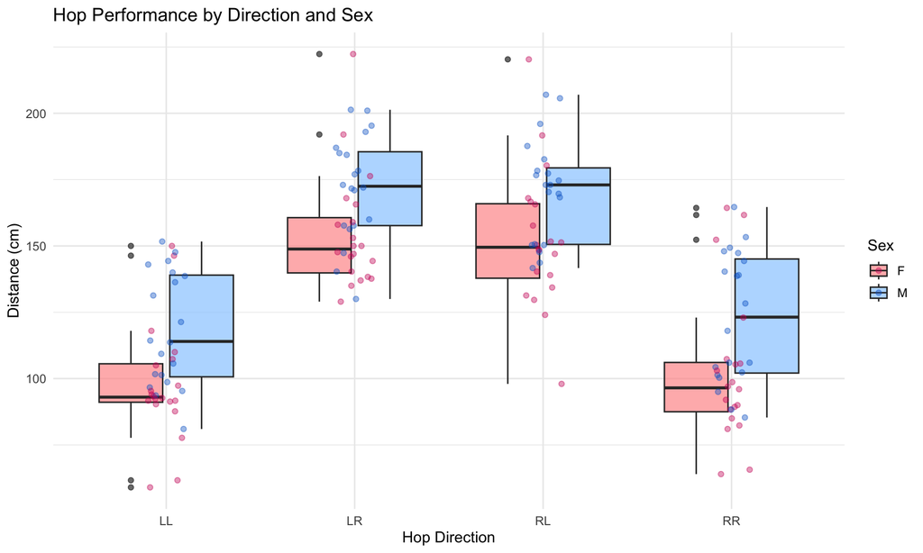

```r
ggplot(perf_long, aes(x = Direction, y = Distance, fill = Sex)) +
  geom_boxplot(alpha = 0.7) +
  geom_jitter(aes(color = Sex), width = 0.1, alpha = 0.4) +
  theme_minimal(base_size = 12) +
  labs(title = "Hop Performance by Direction and Sex", x = "Hop Direction", y = "Distance (cm)") +
  scale_fill_manual(values = c("F" = "#FF9999", "M" = "#99CCFF")) +
  scale_color_manual(values = c("F" = "#CC0066", "M" = "#0066CC"))
```

```r
t_test_perf <- perf_long %>%
  group_by(Direction) %>%
  t_test(Distance ~ Sex) %>%
  add_significance()

kable(t_test_perf %>% select(Direction, statistic, df, p, p.signif),
      caption = "T-Test Results for Performance (Male vs Female)",
      digits = 3,
      col.names = c("Direction", "t", "df", "p", "Sig")) %>%
  kable_styling(bootstrap_options = c("striped", "hover", "condensed"), full_width = FALSE)
```

T-Test Results for Performance (Male vs Female)

Direction

t

df

p

Sig

LL

-2.980

37.972

0.005

LR

-2.584

37.588

0.014

RL

-2.612

34.980

0.013

RR

-2.439

37.393

0.020

## Height-Normalized Performance

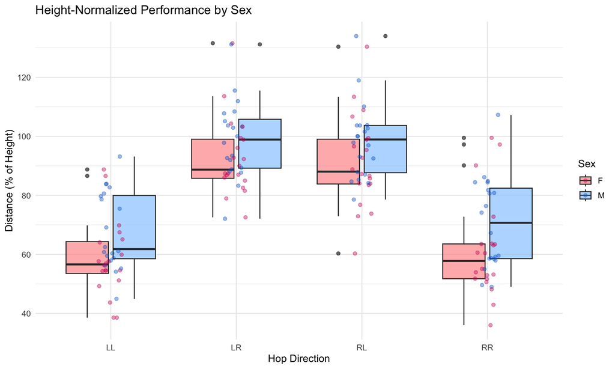

```r
perf_normalized <- perf_with_demo %>%
  mutate(
    LR_Norm = LR_AVG / Height * 100,
    LL_Norm = LL_AVG / Height * 100,
    RL_Norm = RL_AVG / Height * 100,
    RR_Norm = RR_AVG / Height * 100
  )

norm_perf_long <- perf_normalized %>%
  select(ID, Sex, ends_with("_Norm")) %>%
  pivot_longer(cols = ends_with("_Norm"), names_to = "Direction", values_to = "Distance") %>%
  mutate(Direction = gsub("_Norm", "", Direction))

ggplot(norm_perf_long, aes(x = Direction, y = Distance, fill = Sex)) +
  geom_boxplot(alpha = 0.7) +
  geom_jitter(aes(color = Sex), width = 0.1, alpha = 0.4) +
  theme_minimal(base_size = 12) +
  labs(title = "Height-Normalized Performance by Sex", x = "Hop Direction", y = "Distance (% of Height)") +
  scale_fill_manual(values = c("F" = "#FF9999", "M" = "#99CCFF")) +
  scale_color_manual(values = c("F" = "#CC0066", "M" = "#0066CC"))
```

```r
t_test_norm <- norm_perf_long %>%
  group_by(Direction) %>%
  t_test(Distance ~ Sex) %>%
  add_significance()

kable(t_test_norm %>% select(Direction, statistic, df, p, p.signif),
      caption = "T-Test Results for Normalized Performance (Male vs Female)",
      digits = 3,
      col.names = c("Direction", "t", "df", "p", "Sig")) %>%
  kable_styling(bootstrap_options = c("striped", "hover", "condensed"), full_width = FALSE)
```

T-Test Results for Normalized Performance (Male vs Female)

Direction

t

df

p

Sig

LL

-2.284

37.995

0.028

LR

-1.408

37.995

0.167

ns

RL

-1.531

36.564

0.134

ns

RR

-1.793

37.722

0.081

ns

# Summary

**Demographics**: Males and females showed similar age distributions with expected differences in mass and height.

**Biomechanical Angles**: Several landing kinematic angles showed sex-based differences, particularly in hip and trunk flexion.

**Performance**: Males demonstrated greater absolute hopping distances, though most differences diminished when normalized for height.